# palmerpenguins

4주차 펭귄 설문조사

Author

최요한

Published

June 12, 2026

# 1 학습 목표

**Note**

데이터 요약하고 표로 정리하기

탐색적 데이터 분석 (EDA) 실습하기

평균의 함정을 간파하기

(단변량, 이변량, 다변량) 변수의 파악하고 관계 해석하기

# 2 준비사항

## 2.1 tidyverse 로드

> 항상 tidyverse를 로드합니다.

> 한글을 출력하기 위해 showtext 를 로드합니다

```r
library(tidyverse)            # 라이브러리 로드
library(showtext)
showtext_auto()
```

> 다양한 수식을 편리하게 계산할수 있습니다

```r
# install.packages("janitor")        # 최초 1회
library(janitor)                     # 라이브러리 로드
```

## 2.2 penguins 데이터셋 로드

> penguins 설문조사 결과를 출력합니다.

```r
# install.packages("palmerpenguins")        # 최초 1회
library(palmerpenguins)                     # 라이브러리 로드
```

## 2.3 데이터셋 출력

```r
penguins
```

```
# A tibble: 344 × 8
   species island    bill_length_mm bill_depth_mm flipper_length_mm body_mass_g
   <fct>   <fct>              <dbl>         <dbl>             <int>       <int>
 1 Adelie  Torgersen           39.1          18.7               181        3750
 2 Adelie  Torgersen           39.5          17.4               186        3800
 3 Adelie  Torgersen           40.3          18                 195        3250
 4 Adelie  Torgersen           NA            NA                  NA          NA
 5 Adelie  Torgersen           36.7          19.3               193        3450
 6 Adelie  Torgersen           39.3          20.6               190        3650
 7 Adelie  Torgersen           38.9          17.8               181        3625
 8 Adelie  Torgersen           39.2          19.6               195        4675
 9 Adelie  Torgersen           34.1          18.1               193        3475
10 Adelie  Torgersen           42            20.2               190        4250
# ℹ 334 more rows
# ℹ 2 more variables: sex <fct>, year <int>
```

# 3 [남극복지재단] 설문조사 결측치 파악

## 3.1 설문에 참여한 펭귄의 데이터셋을 출력합니다

```r
penguins
```

```
# A tibble: 344 × 8
   species island    bill_length_mm bill_depth_mm flipper_length_mm body_mass_g
   <fct>   <fct>              <dbl>         <dbl>             <int>       <int>
 1 Adelie  Torgersen           39.1          18.7               181        3750
 2 Adelie  Torgersen           39.5          17.4               186        3800
 3 Adelie  Torgersen           40.3          18                 195        3250
 4 Adelie  Torgersen           NA            NA                  NA          NA
 5 Adelie  Torgersen           36.7          19.3               193        3450
 6 Adelie  Torgersen           39.3          20.6               190        3650
 7 Adelie  Torgersen           38.9          17.8               181        3625
 8 Adelie  Torgersen           39.2          19.6               195        4675
 9 Adelie  Torgersen           34.1          18.1               193        3475
10 Adelie  Torgersen           42            20.2               190        4250
# ℹ 334 more rows
# ℹ 2 more variables: sex <fct>, year <int>
```

## 3.2 설문조사의 항목들을 확인합니다

```r
penguins |>
  colnames()
```

```
[1] "species"           "island"            "bill_length_mm"
[4] "bill_depth_mm"     "flipper_length_mm" "body_mass_g"
[7] "sex"               "year"
```

## 3.3 데이터셋의 구조를 확인합니다

```r
penguins |>
  glimpse()
```

```
Rows: 344
Columns: 8
$ species           <fct> Adelie, Adelie, Adelie, Adelie, Adelie, Adelie, Adel…
$ island            <fct> Torgersen, Torgersen, Torgersen, Torgersen, Torgerse…
$ bill_length_mm    <dbl> 39.1, 39.5, 40.3, NA, 36.7, 39.3, 38.9, 39.2, 34.1, …
$ bill_depth_mm     <dbl> 18.7, 17.4, 18.0, NA, 19.3, 20.6, 17.8, 19.6, 18.1, …
$ flipper_length_mm <int> 181, 186, 195, NA, 193, 190, 181, 195, 193, 190, 186…
$ body_mass_g       <int> 3750, 3800, 3250, NA, 3450, 3650, 3625, 4675, 3475, …
$ sex               <fct> male, female, female, NA, female, male, female, male…
$ year              <int> 2007, 2007, 2007, 2007, 2007, 2007, 2007, 2007, 2007…
```

## 3.4 설문조사 값이 모두 똑같은 펭귄이 있는지 확인합니다

> 다행이 0건입니다.

```r
library(janitor)

penguins |>
  janitor::get_dupes()
```

```
# A tibble: 0 × 9
# ℹ 9 variables: species <fct>, island <fct>, bill_length_mm <dbl>,
#   bill_depth_mm <dbl>, flipper_length_mm <int>, body_mass_g <int>, sex <fct>,
#   year <int>, dupe_count <int>
```

**소스 코드 확인하기**

```r
mpg |>
  get_dupes()
```

**소스 코드 확인하기**

```r
diamonds |>
  get_dupes()
```

## 3.5 설문조사에 결측치가 있는지 확인합니다

```r
penguins |>
  is.na() |>
  colSums() |>
  enframe()
```

```
# A tibble: 8 × 2
  name              value
  <chr>             <dbl>
1 species               0
2 island                0
3 bill_length_mm        2
4 bill_depth_mm         2
5 flipper_length_mm     2
6 body_mass_g           2
7 sex                  11
8 year                  0
```

## 3.6 결측치 처리하는 방법을 결정합니다

**결측치 모두 제거**

penguins |> drop_na() penguins |> drop_na(bill_length_mm)

**결측치 0으로 변환**

penguins |> mutate(body_mass_g = replace_na(body_mass_g, 0))

**결측치 평균으로 변환**

penguins |>  
mutate(bill_length_mm = replace_na(bill_length_mm, mean(bill_length_mm,  
na.rm = TRUE)))

**결측치 모름으로 변환**

penguins |> mutate(sex = fct_na_value_to_level(sex, level = “Unknown”))

## 3.7 결측치가 있는 경우

### 3.7.1 결측치가 하나도 없는 펭귄이 몇마리인지 확인합니다.

> 333마리

```r
penguins |>
  drop_na()
```

```
# A tibble: 333 × 8
   species island    bill_length_mm bill_depth_mm flipper_length_mm body_mass_g
   <fct>   <fct>              <dbl>         <dbl>             <int>       <int>
 1 Adelie  Torgersen           39.1          18.7               181        3750
 2 Adelie  Torgersen           39.5          17.4               186        3800
 3 Adelie  Torgersen           40.3          18                 195        3250
 4 Adelie  Torgersen           36.7          19.3               193        3450
 5 Adelie  Torgersen           39.3          20.6               190        3650
 6 Adelie  Torgersen           38.9          17.8               181        3625
 7 Adelie  Torgersen           39.2          19.6               195        4675
 8 Adelie  Torgersen           41.1          17.6               182        3200
 9 Adelie  Torgersen           38.6          21.2               191        3800
10 Adelie  Torgersen           34.6          21.1               198        4400
# ℹ 323 more rows
# ℹ 2 more variables: sex <fct>, year <int>
```

### 3.7.2 결측치가 하나라도 있는 펭귄이 몇마리인지 확인합니다.

> 11마리

```r
penguins |>
  filter(
    if_any(everything(),is.na)
  )
```

```
# A tibble: 11 × 8
   species island    bill_length_mm bill_depth_mm flipper_length_mm body_mass_g
   <fct>   <fct>              <dbl>         <dbl>             <int>       <int>
 1 Adelie  Torgersen           NA            NA                  NA          NA
 2 Adelie  Torgersen           34.1          18.1               193        3475
 3 Adelie  Torgersen           42            20.2               190        4250
 4 Adelie  Torgersen           37.8          17.1               186        3300
 5 Adelie  Torgersen           37.8          17.3               180        3700
 6 Adelie  Dream               37.5          18.9               179        2975
 7 Gentoo  Biscoe              44.5          14.3               216        4100
 8 Gentoo  Biscoe              46.2          14.4               214        4650
 9 Gentoo  Biscoe              47.3          13.8               216        4725
10 Gentoo  Biscoe              44.5          15.7               217        4875
11 Gentoo  Biscoe              NA            NA                  NA          NA
# ℹ 2 more variables: sex <fct>, year <int>
```

**Note**

[알립니다]

1. 남극복지재단은 설문조사 비용과 표본 확보의 어려움을 고려해 결측치가 있는 펭귄을 포함하는 것이 보다 정확한 설문조사가된다고 판단하였습니다.
2. 결측치가 있는 11마리를 포함해 총 344마리 모두 분석해주실 것을 요청드립니다.

# 4 단일 항목 분석

## 4.1 일련번호 부여

> 분석의 편리함을 위해 분석에서만 사용할 가상의 일련번호를 부여합니다

```r
penguins |>
  mutate(number = row_number(), .before = 1) -> penguins_1_number

penguins_1_number
```

```
# A tibble: 344 × 9
   number species island    bill_length_mm bill_depth_mm flipper_length_mm
    <int> <fct>   <fct>              <dbl>         <dbl>             <int>
 1      1 Adelie  Torgersen           39.1          18.7               181
 2      2 Adelie  Torgersen           39.5          17.4               186
 3      3 Adelie  Torgersen           40.3          18                 195
 4      4 Adelie  Torgersen           NA            NA                  NA
 5      5 Adelie  Torgersen           36.7          19.3               193
 6      6 Adelie  Torgersen           39.3          20.6               190
 7      7 Adelie  Torgersen           38.9          17.8               181
 8      8 Adelie  Torgersen           39.2          19.6               195
 9      9 Adelie  Torgersen           34.1          18.1               193
10     10 Adelie  Torgersen           42            20.2               190
# ℹ 334 more rows
# ℹ 3 more variables: body_mass_g <int>, sex <fct>, year <int>
```

# 5 데이터 정리(Janitor)

## 5.1 패키지 설치

```r
# install.packages("janitor")        # 최초 1회
library(janitor)                     # 라이브러리 로드
```

## 5.2 빈도표 정리

> 엑셀로 하던 작업을 janitor 패키지를 사용해 수행할 수 있습니다

```r
penguins |>
  tabyl(species)
```

```
   species   n   percent
    Adelie 152 0.4418605
 Chinstrap  68 0.1976744
    Gentoo 124 0.3604651
```

### 5.2.1 변수 2개

```r
penguins |>
  tabyl(species, sex)
```

```
   species female male NA_
    Adelie     73   73   6
 Chinstrap     34   34   0
    Gentoo     58   61   5
```

### 5.2.2 변수 3개

```r
penguins |>
  tabyl(species, sex, island)
```

```
$Biscoe
   species female male NA_
    Adelie     22   22   0
 Chinstrap      0    0   0
    Gentoo     58   61   5

$Dream
   species female male NA_
    Adelie     27   28   1
 Chinstrap     34   34   0
    Gentoo      0    0   0

$Torgersen
   species female male NA_
    Adelie     24   23   5
 Chinstrap      0    0   0
    Gentoo      0    0   0
```

## 5.3 합계

> 가로 합계

```r
penguins |>
  tabyl(species, sex) |>
  adorn_totals(c("col"))
```

```
   species female male NA_ Total
    Adelie     73   73   6   152
 Chinstrap     34   34   0    68
    Gentoo     58   61   5   124
```

> 세로 합계

```r
penguins |>
  tabyl(species, sex) |>
  adorn_totals(c("row"))
```

```
   species female male NA_
    Adelie     73   73   6
 Chinstrap     34   34   0
    Gentoo     58   61   5
     Total    165  168  11
```

> 가로, 세로 합계

```r
penguins |>
  tabyl(species, sex) |>
  adorn_totals(c("col", "row"))
```

```
   species female male NA_ Total
    Adelie     73   73   6   152
 Chinstrap     34   34   0    68
    Gentoo     58   61   5   124
     Total    165  168  11   344
```

## 5.4 비율(퍼센트)

> 비중 구하기

```r
penguins |>
  tabyl(species, sex) |>
  adorn_percentages("row")
```

```
   species    female      male        NA_
    Adelie 0.4802632 0.4802632 0.03947368
 Chinstrap 0.5000000 0.5000000 0.00000000
    Gentoo 0.4677419 0.4919355 0.04032258
```

> 소수 자리수

```r
penguins |>
  tabyl(species, sex) |>
  adorn_percentages("row") |>
  adorn_pct_formatting(digits = 0)
```

```
   species female male NA_
    Adelie    48%  48%  4%
 Chinstrap    50%  50%  0%
    Gentoo    47%  49%  4%
```

## 5.5 합계와 퍼센트

```r
penguins |>
  tabyl(species, sex) |>
  adorn_percentages("row") |>
  adorn_pct_formatting(digits = 0) |>
  adorn_ns(position = "front")
```

```
   species   female     male    NA_
    Adelie 73 (48%) 73 (48%) 6 (4%)
 Chinstrap 34 (50%) 34 (50%) 0 (0%)
    Gentoo 58 (47%) 61 (49%) 5 (4%)
```

```r
penguins |>
  tabyl(species, sex) |>
  adorn_percentages("row") |>
  adorn_pct_formatting(digits = 0) |>
  adorn_ns(position = "rear")
```

```
   species   female     male    NA_
    Adelie 48% (73) 48% (73) 4% (6)
 Chinstrap 50% (34) 50% (34) 0% (0)
    Gentoo 47% (58) 49% (61) 4% (5)
```

```r
penguins |>
  tabyl(species, sex) |>
  adorn_totals(c("col", "row")) |>
  adorn_percentages("row") |>
  adorn_pct_formatting(digits = 0) |>
  adorn_ns(position = "front")
```

```
   species    female      male     NA_      Total
    Adelie  73 (48%)  73 (48%)  6 (4%) 152 (100%)
 Chinstrap  34 (50%)  34 (50%)  0 (0%)  68 (100%)
    Gentoo  58 (47%)  61 (49%)  5 (4%) 124 (100%)
     Total 165 (48%) 168 (49%) 11 (3%) 344 (100%)
```

# 6 탐색적 데이터 분석

## 6.1 GGally 패키지 로드

> 여러 변수간의 관계를 조망하는 패키지입니다

```r
#install.packages("GGally")      #최초 1회
library(GGally)
```

## 6.2 ggpairs

> 데이터 분석 초기 단계에서 변수들의 분포와 선형관계 등을 훓어보는 탐색적 데이터 분석 입니다.

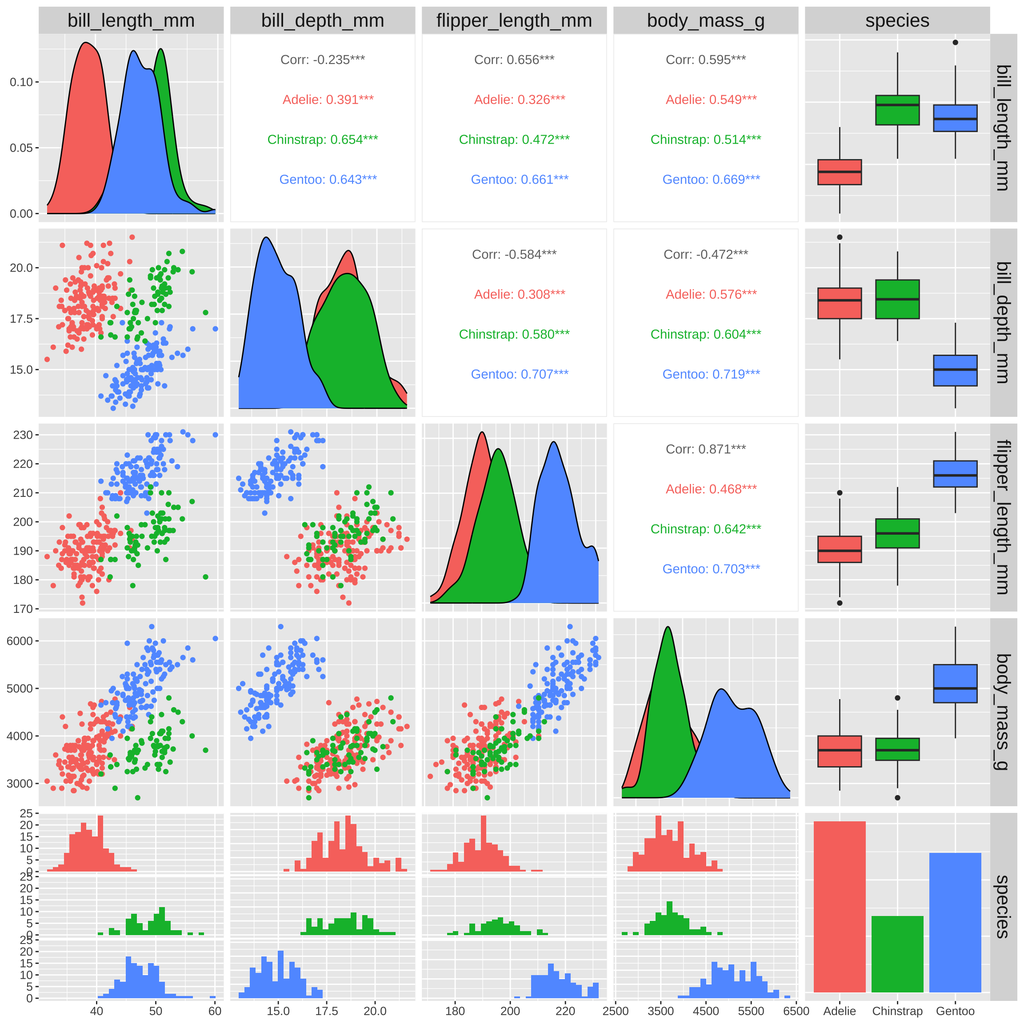

```r
penguins |>
  ggpairs(columns = c("bill_length_mm",
                      "bill_depth_mm",
                      "flipper_length_mm",
                      "body_mass_g",
                      "species"),
          aes(color = species)
          ) +
  theme(
    strip.text = element_text(size = 16),
    axis.text = element_text(size = 10)
  )
```

> 종족별로 부리의 길이, 두께, 지느러미, 체중의 유의미한 특성을 확인할 수 있습니다

## 6.3 종족별 펭귄수 확인(species)

```r
penguins_1_number |>
  count(species)
```

```
# A tibble: 3 × 2
  species       n
  <fct>     <int>
1 Adelie      152
2 Chinstrap    68
3 Gentoo      124
```

### 6.3.1 막대그래프 시각화

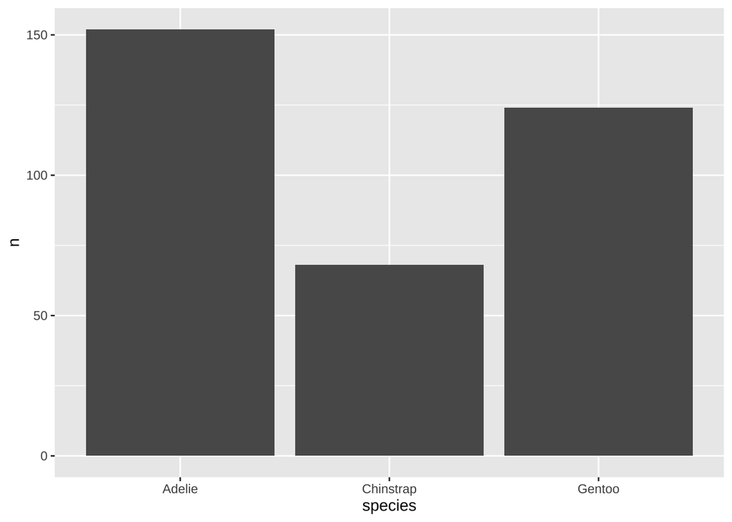

```r
penguins_1_number |>
  count(species) |>
  ggplot(aes(x = species, y= n)) +
  geom_bar(stat = 'identity')
```

### 6.3.2 값 입력

> geom_label 혹은 geom_text

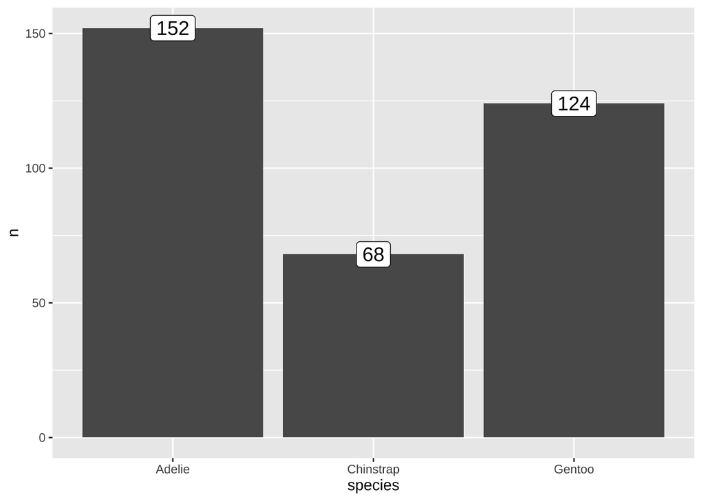

```r
penguins_1_number |>
  count(species) |>
  ggplot(aes(x = species, y= n)) +
  geom_bar(stat = 'identity') +
  geom_label(aes(label = n), size = 5)
```

### 6.3.3 시각화 테마

> theme_minimal(), theme_classic(), theme_dark(), theme_bw(), theme_void()

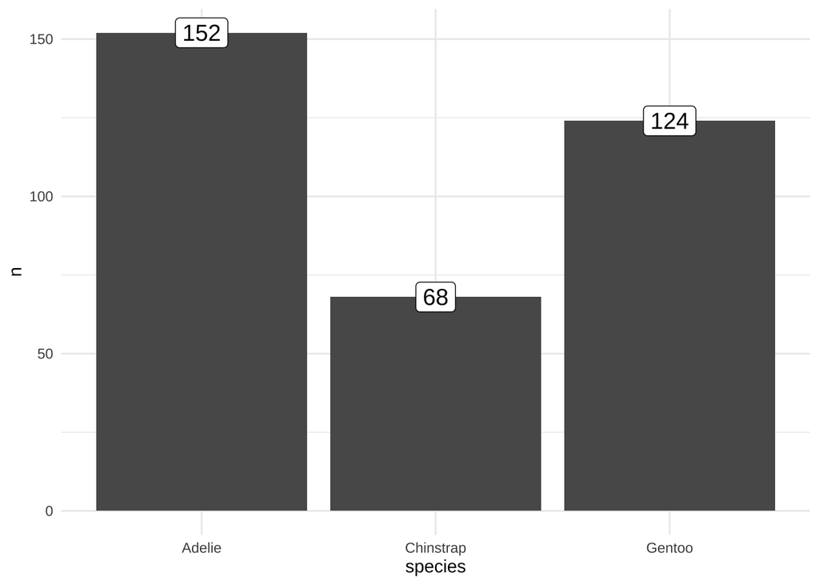

```r
penguins_1_number |>
  count(species) |>
  ggplot(aes(x = species, y= n)) +
  geom_bar(stat = 'identity') +
  geom_label(aes(label = n), size = 5) +
  theme_minimal()
```

## 6.4 bbplot

> install.packages(‘devtools’)

> devtools::install_github(‘bbc/bbplot’)

> library(bbplot)

```r
# install.packages('devtools')
# devtools::install_github('bbc/bbplot')
library(bbplot)
```

### 6.4.1 bbc_style()

> bbplot::bbc_style()

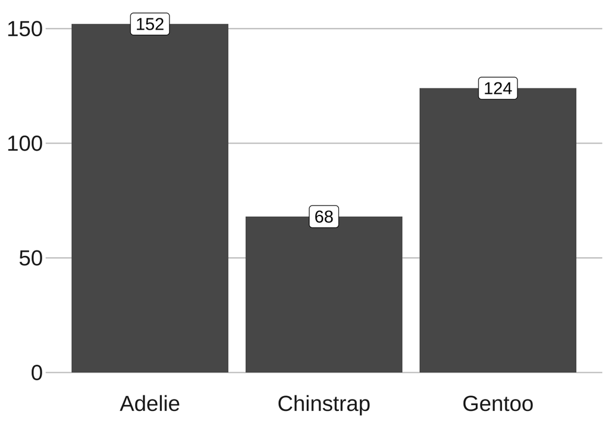

```r
penguins_1_number |>
  count(species) |>
  ggplot(aes(x = species, y= n)) +
  geom_bar(stat = 'identity') +
  geom_label(aes(label = n), size = 5) +
  bbplot::bbc_style()
```

🔗 [링크](https://bbc.github.io/rcookbook/)

## 6.5 범주형 데이터 확인

> Q1. island를 기준으로 펭귄수를 구하세요.

> Q2. 위의 표를 막대그래프로 시각화세요.

> Q3. 생물학적 성별(sex)을 기준으로 펭귄수를 구하세요

> Q4. 위의 표를 막대그래프로 시각화세요.

# 7 교차분석

## 7.1 서식지별로 종족 분포를 표로 정리합니다

```r
penguins_1_number |>
  count(species, island)
```

```
# A tibble: 5 × 3
  species   island        n
  <fct>     <fct>     <int>
1 Adelie    Biscoe       44
2 Adelie    Dream        56
3 Adelie    Torgersen    52
4 Chinstrap Dream        68
5 Gentoo    Biscoe      124
```

## 7.2 히트맵으로 시각화합니다

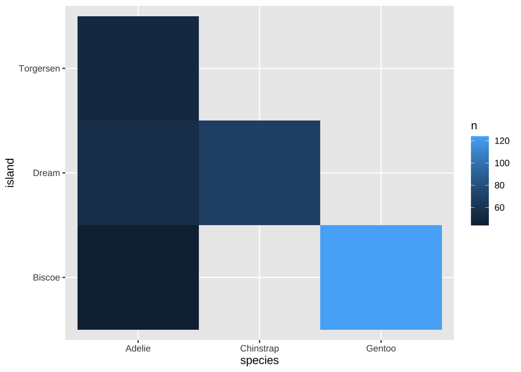

```r
penguins_1_number |>
  count(species, island) |>
  ggplot(aes(x = species, y = island, fill = n)) +
  geom_tile()
```

## 7.3 값을 입력합니다

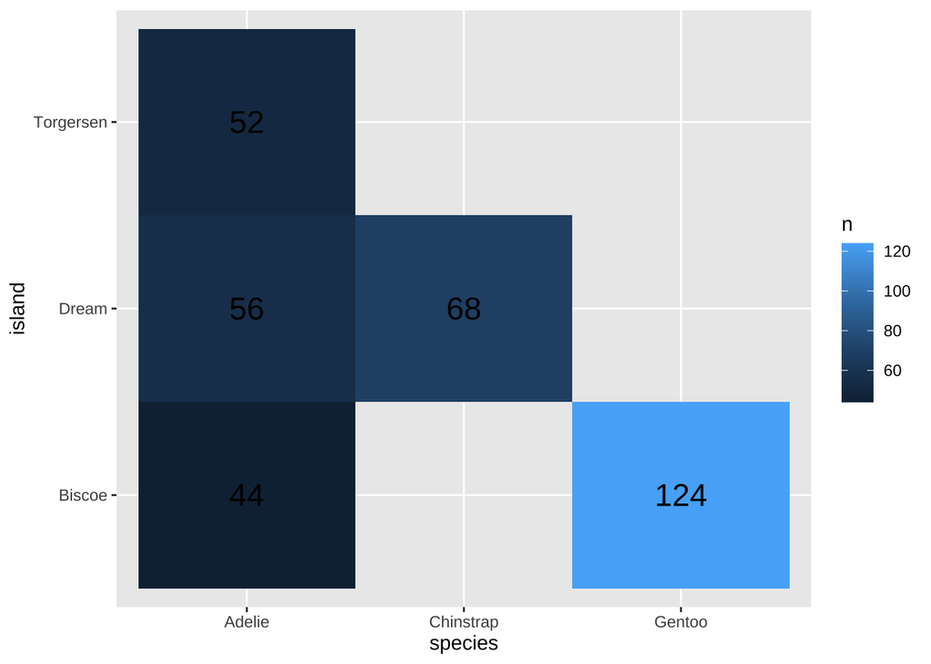

```r
penguins_1_number |>
  count(species, island) |>
  ggplot(aes(x = species, y = island, fill = n)) +
  geom_tile() +
  geom_text(aes(label = n), size = 6, size = 'snow')
```

## 7.4 테마를 적용하고 꾸며줍니다

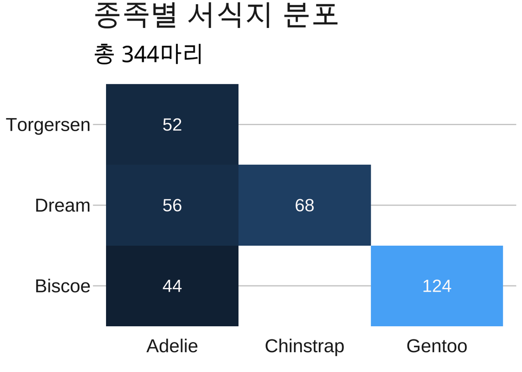

```r
penguins_1_number |>
  count(species, island) |>
  ggplot(aes(x = species, y = island, fill = n)) +
  geom_tile() +
  geom_text(aes(label = n), size = 6, color = 'snow') +
  bbc_style() +
  theme(legend.position = 'none') +
  labs(title = '종족별 서식지 분포', subtitle = '총 344마리')
```

## 7.5 3가지 변수 교차 분석

> species, island, sex, facet_wrap()

[figure not shown]

```r
penguins_1_number |>
  count(species, island, sex) |>
  ggplot(aes(x = species, y = island, fill = n)) +
  geom_tile() +
  geom_text(aes(label = n), size = 6, color = 'snow') +
  bbc_style() +
  theme(legend.position = 'none') +
  labs(title = '종족별 서식지 분포',
       subtitle = "333마리") +
  facet_wrap(.~sex)
```

## 7.6 성별 결측값 제외

> drop_na(sex)

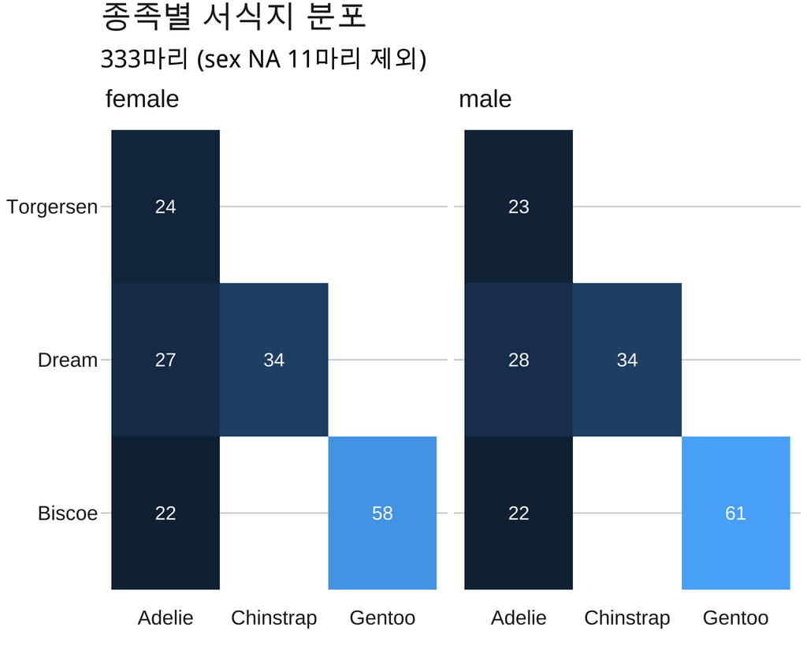

```r
penguins_1_number |>
  drop_na(sex) |>
  count(species, island, sex) |>
  ggplot(aes(x = species, y = island, fill = n)) +
  geom_tile() +
  geom_text(aes(label = n), size = 6, color = 'snow') +
  bbc_style() +
  theme(legend.position = 'none') +
  labs(title = '종족별 서식지 분포',
       subtitle = "333마리 (sex NA 11마리 제외)") +
  facet_wrap(.~sex)
```

# 8 연속형 변수의 분포

## 8.1 히스토그램

> geom_histogram()

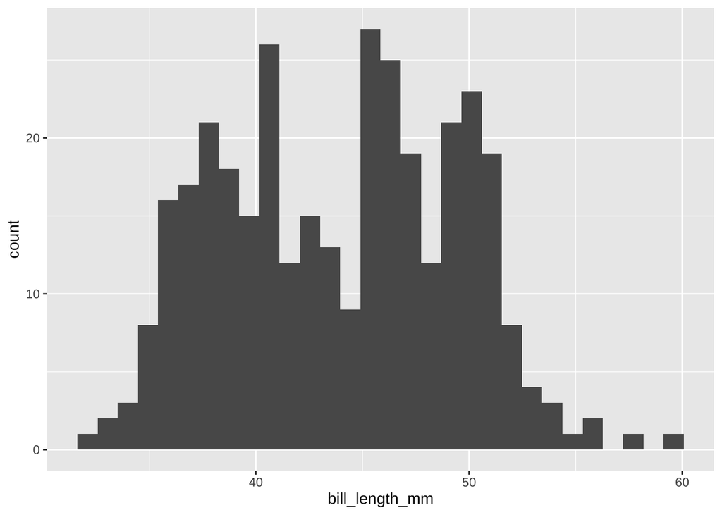

```r
penguins_1_number |>
  ggplot(aes(x = bill_length_mm)) +
  geom_histogram()
```

### 8.1.1 히스토그램의 종족별 구분

> ggplot(aes(x = bill_length_mm))

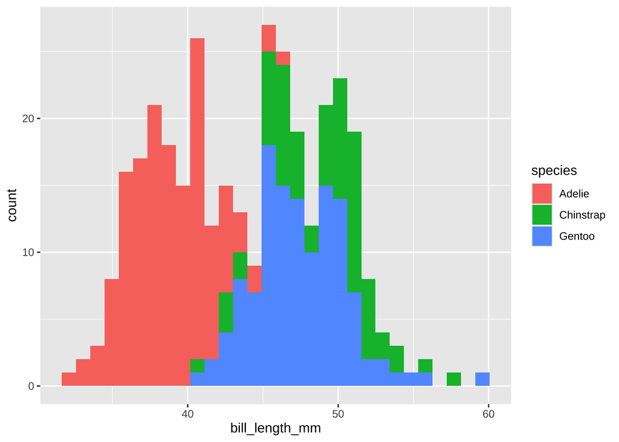

```r
penguins_1_number |>
  ggplot(aes(x = bill_length_mm)) +
  geom_histogram(aes(fill = species))
```

### 8.1.2 종족별 면분할

> facet_wrap()

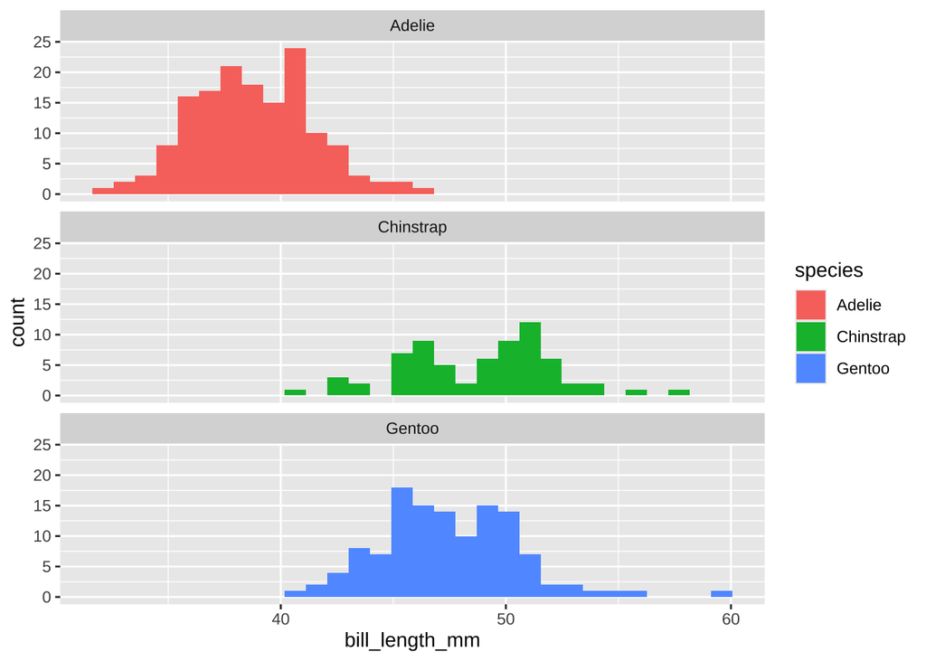

```r
penguins_1_number |>
  ggplot(aes(x = bill_length_mm, fill = species)) +
  geom_histogram() +
  facet_wrap(.~species, ncol = 1)
```

### 8.1.3 테마를 적용하고 꾸며줍니다

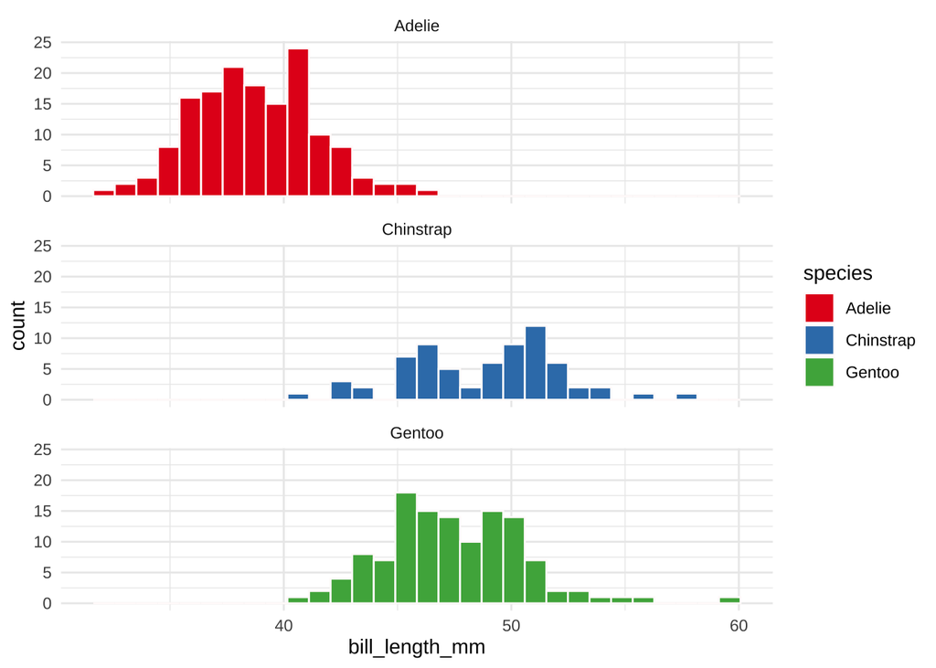

```r
penguins_1_number |>
  ggplot(aes(x = bill_length_mm, fill = species)) +
  geom_histogram(color = 'snow') +
  facet_wrap(.~species, ncol = 1) +
  scale_fill_brewer(palette = 'Set1') +
  theme_minimal()
```

```r
RColorBrewer::display.brewer.all()
```

### 8.1.4 Gentoo 펭귄의 이봉분포를 확인합니다

> 수컷과 암컷의 차이를 확인합니다.

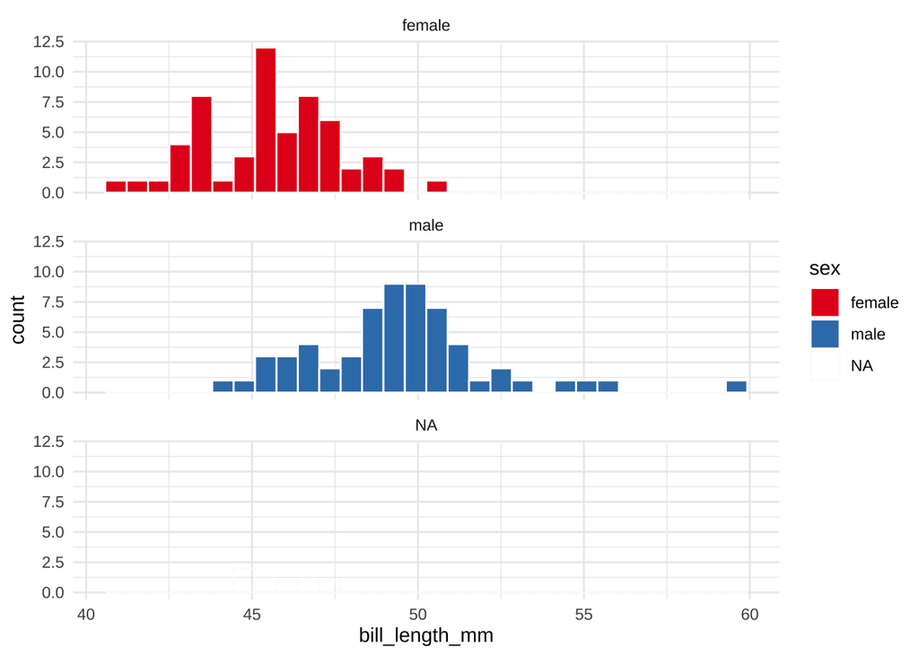

```r
penguins_1_number |>
  filter(species == 'Gentoo') |>
  #drop_na(sex) |>
  ggplot(aes(x = bill_length_mm, fill = sex)) +
  geom_histogram(color = 'snow') +
  facet_wrap(.~sex, ncol = 1) +
  scale_fill_brewer(palette = 'Set1') +
  theme_minimal()
```

### 8.1.5 밀도함수 (확률분포)를 확인합니다

> geom_density()

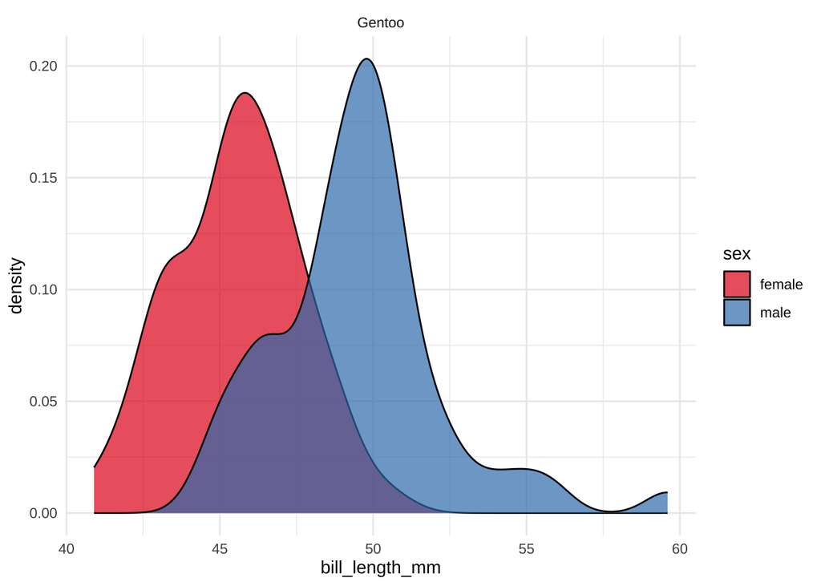

```r
penguins_1_number |>
  filter(species == 'Gentoo') |>
  drop_na(sex) |>
  ggplot(aes(x = bill_length_mm, fill = sex)) +
  geom_density(alpha = .7)  +
  facet_wrap(.~species, ncol = 1) +
  scale_fill_brewer(palette = 'Set1') +
  theme_minimal()
```

# 9 리포트

## 9.1 데이터 품질 및 무결성 검증 (결측치 파악)

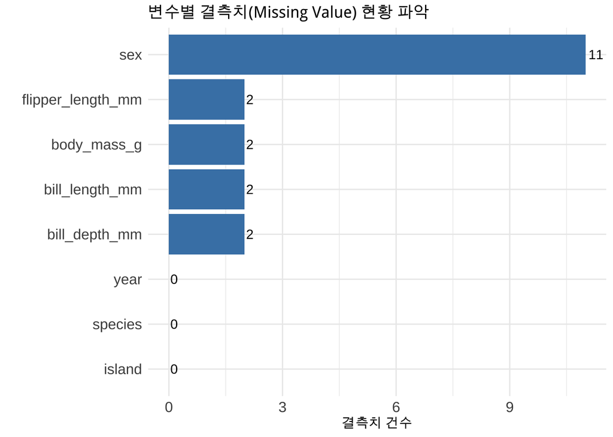

```r
penguins |>
  is.na() |>
  colSums() |>
  enframe(name = "변수명", value = "결측치_건수") |>
  ggplot(aes(x = reorder(변수명, 결측치_건수), y = 결측치_건수)) +
  geom_bar(fill = "steelblue", stat = 'identity') +
  geom_text(aes(label = 결측치_건수), hjust = -0.2) +
  coord_flip() +
  labs(title = "변수별 결측치(Missing Value) 현황 파악",
       x = "",
       y = "결측치 건수") +
  theme_minimal() +
  theme(
    axis.text = element_text(size = 12)
  )
```

## 9.2 대상자/표본의 기본 분포 (Baseline Demographics)

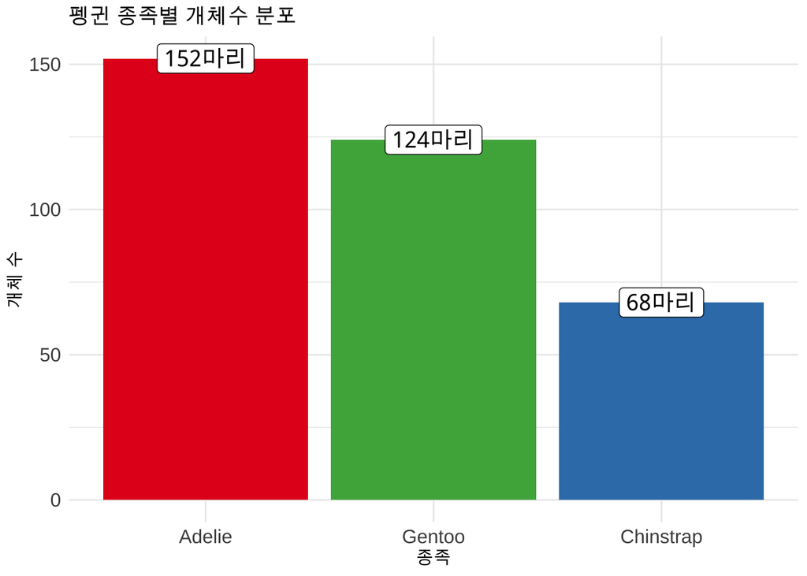

```r
# 타겟 그룹(종족)의 모집단 구성 비율 확인
penguins_1_number |>
  count(species) |>
  ggplot(aes(x = reorder(species, -n), y = n, fill = species)) +
  geom_bar(stat = "identity", show.legend = FALSE) +
  geom_label(aes(label = paste0(n, "마리")), size = 5, fill = "white") +
  labs(title = "펭귄 종족별 개체수 분포",
       x = "종족", y = "개체 수") +
  theme_minimal() +
  scale_fill_brewer(palette = 'Set1') +
    theme(
    axis.text = element_text(size = 12)
    )
```

## 9.3 지리적 위치별 접근성

> .

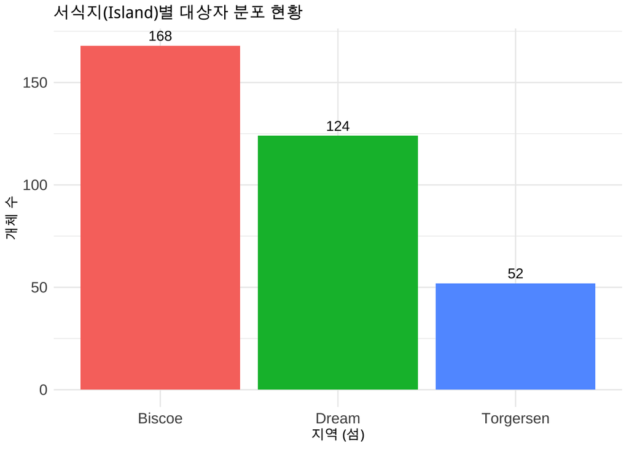

```r
# 사업 대상 지역(섬)별 표본 분포 파악
penguins_1_number |>
  count(island) |>
  ggplot(aes(x = island, y = n, fill = island)) +
  geom_col(show.legend = FALSE) +
  geom_text(aes(label = n), vjust = -0.5, size = 4) +
  labs(title = "서식지(Island)별 대상자 분포 현황", x = "지역 (섬)", y = "개체 수") +
  theme_minimal() +
  theme(
    axis.text = element_text(size = 12)
    )
```

## 9.4 주요 지표간 다변량 상관관계 분석

> - 전체로 볼 때 부리 길이와 두께는 음의 상관과계를 갖지만 (-0.235) 종족별로 나누어 관찰하면 부리의 길이가 길수록 두께도 두꺼워지는 양의 상관관계를 갖습니다.
>   - Adelie: 0.391 // Chinstrap: 0.654 // Gentoo: 0.643
> - 날개와 체중은 매우 강한 양의 상관관계를 갖습니다. (0.871)
>   - 체중이 무거울수록 날개도 긴 경향이 확연히 확인됩니다
> - Chinstrap 펭귄과 Adelie 펭귄은 부리 두께, 날개, 체중이 비슷하지만 부리 길이가 확연히 다릅니다. Chinstrap 펭귄이 훨신 길어서 부리로 두 종류의 펭귄을 구분해야 합니다.

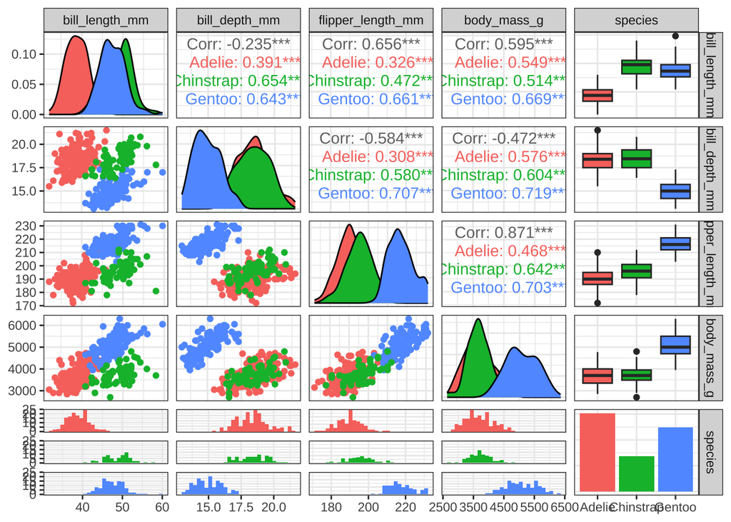

```r
penguins |>
  ggpairs(columns = c("bill_length_mm",
                      "bill_depth_mm",
                      "flipper_length_mm",
                      "body_mass_g",
                      "species"),
          aes(color = species)
          ) +
  theme(
    strip.text = element_text(size = 16),
    axis.text = element_text(size = 10)
  ) +
  theme_bw()
```

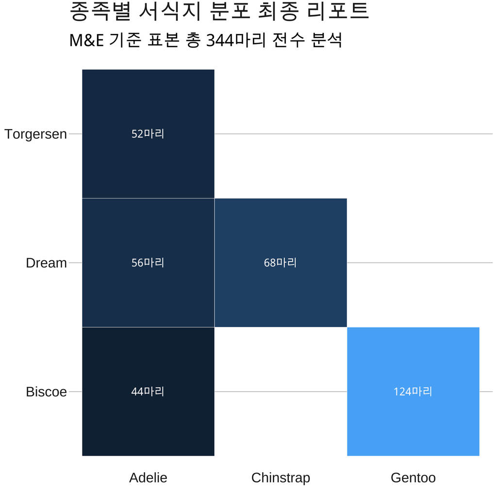

```r
# 지역과 종족을 교차하여 특정 커뮤니티 구조 파악 (히트맵)
# 실제 강의안 문서에 작성하셨던 bbplot(BBC 테마) 스타일을 적용한 최종 성과 보고용 플롯
# (패키지가 설치되어 있고 폰트가 로드된 상태에서 작동합니다)
penguins_1_number |>
  count(species, island) |>
  ggplot(aes(x = species, y = island, fill = n)) +
  geom_tile(color = 'snow') +
  geom_text(aes(label = paste0(n, "마리")), size = 5, color = "snow") +
  bbplot::bbc_style() +
  theme(legend.position = "none") +
  labs(title = "종족별 서식지 분포 최종 리포트",
       subtitle = "M&E 기준 표본 총 344마리 전수 분석")
```

## 9.5 bill_length_mm와 bill_depth_mm의 관계

> Adelie, Gentoo, Chinstrap 펭귄 부리는 종족과 관계없이 길수록 두껍다는 것을 확인하였다

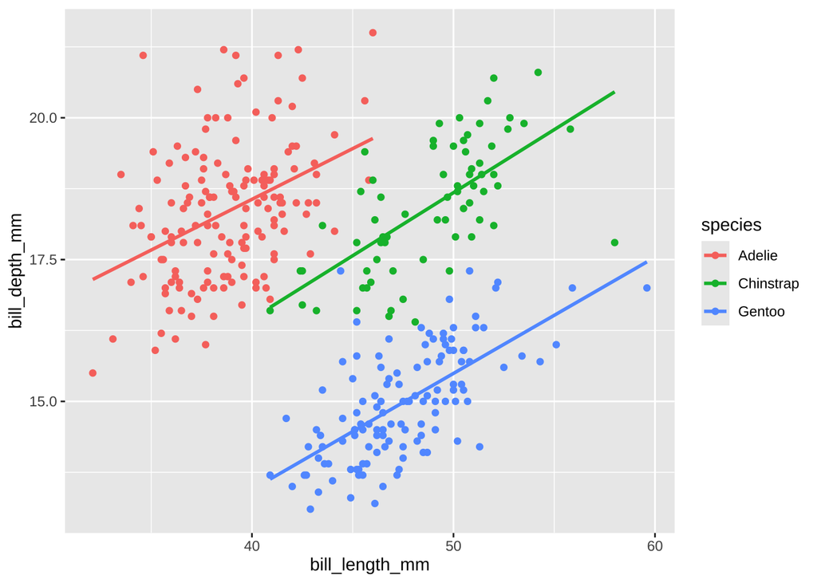

```r
penguins |>
  ggplot(aes(x = bill_length_mm, y = bill_depth_mm, color = species)) +
  geom_point() +
  geom_smooth(method = 'lm', se = F)
```